# Risk Factor Analysis

## Outcome Variable

**Outcome Variable:** stunted

## Predictor Variables

**Intervention Variable:** fhtcm

**Adjustment Set:**

unadjusted

## Stratifying Variables

The analysis was stratified on these variable(s):

- agecat
- studyid

The following strata were considered:

- agecat: 12 months, studyid: ki1000304b-SAS-FoodSuppl
- agecat: 12 months, studyid: ki1101329-Keneba
- agecat: 12 months, studyid: ki1135781-COHORTS
- agecat: 18 months, studyid: ki1000304b-SAS-FoodSuppl
- agecat: 18 months, studyid: ki1101329-Keneba
- agecat: 18 months, studyid: ki1135781-COHORTS
- agecat: 24 months, studyid: ki1101329-Keneba
- agecat: 24 months, studyid: ki1135781-COHORTS
- agecat: 3 months, studyid: ki1000304b-SAS-FoodSuppl
- agecat: 3 months, studyid: ki1101329-Keneba
- agecat: 3 months, studyid: ki1135781-COHORTS
- agecat: 6 months, studyid: ki1000304b-SAS-FoodSuppl
- agecat: 6 months, studyid: ki1101329-Keneba
- agecat: 6 months, studyid: ki1135781-COHORTS
- agecat: 9 months, studyid: ki1000304b-SAS-FoodSuppl
- agecat: 9 months, studyid: ki1101329-Keneba
- agecat: 9 months, studyid: ki1135781-COHORTS
- agecat: Birth, studyid: ki1101329-Keneba
- agecat: Birth, studyid: ki1135781-COHORTS

### Dropped Strata

Some strata were dropped due to rare outcomes:

- agecat: 12 months, studyid: ki1000304b-SAS-FoodSuppl
- agecat: 12 months, studyid: ki1135781-COHORTS
- agecat: 18 months, studyid: ki1000304b-SAS-FoodSuppl
- agecat: 18 months, studyid: ki1135781-COHORTS
- agecat: 24 months, studyid: ki1135781-COHORTS
- agecat: 3 months, studyid: ki1000304b-SAS-FoodSuppl
- agecat: 3 months, studyid: ki1135781-COHORTS
- agecat: 6 months, studyid: ki1000304b-SAS-FoodSuppl
- agecat: 6 months, studyid: ki1135781-COHORTS
- agecat: 9 months, studyid: ki1000304b-SAS-FoodSuppl
- agecat: 9 months, studyid: ki1135781-COHORTS
- agecat: Birth, studyid: ki1135781-COHORTS

## Methods Detail

We’re interested in the causal parameters $E[Y_a]$ for all values of $a \in \mathcal{A}$. These parameters represent the mean outcome if, possibly contrary to fact, we intervened to set all units to have $A=a$. Under the randomization and positivity assumptions, these are identified by the statistical parameters $\psi_a=E_W[E_{Y|A,W}(Y|A=a,W)]$. In addition, we’re interested in the mean of $Y$, $E[Y]$ under no intervention (the observed mean). We will estimate these parameters by using SuperLearner to fit the relevant likelihood factors – $E_{Y|A,W}(Y|A=a,W)$ and $p(A=a|W)$, and then updating our likelihood fit using a joint TMLE.

For unadjusted analyses ($W=\{\}$), initial likelihoods were estimated using Lrnr_glm to estimate the simple $E(Y|A)$ and Lrnr_mean to estimate $p(A)$. For adjusted analyses, a small library containing Lrnr_glmnet, Lrnr_xgboost, and Lrnr_mean was used.

Having estimated these parameters, we will then use the delta method to estimate relative risks and attributable risks relative to a prespecified baseline level of $A$.

# Results Detail

## Results Plots

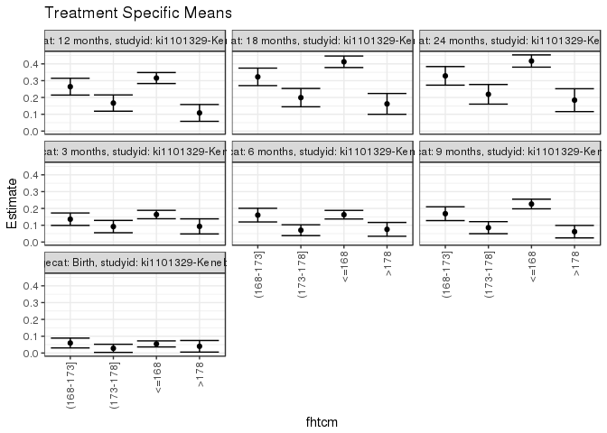

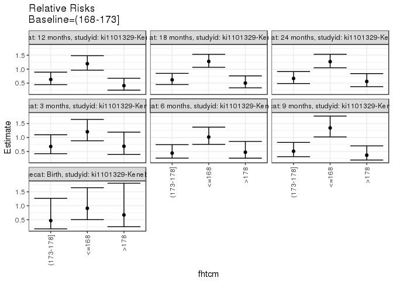

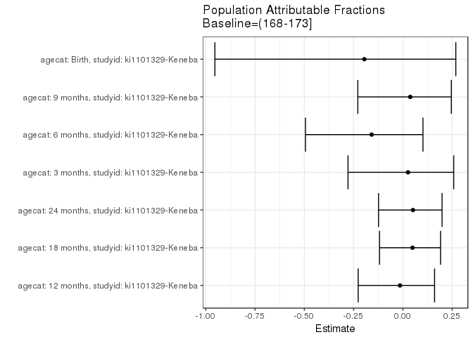

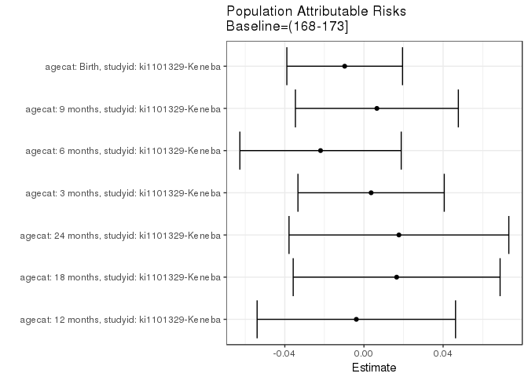

## Data Summary

| agecat | studyid | A | n | nA | nAY0 | nAY1 |
| --- | --- | --- | --- | --- | --- | --- |
| 12 months | ki1000304b-SAS-FoodSuppl | (168-173] | 91 | 6 | 0 | 6 |
| 12 months | ki1000304b-SAS-FoodSuppl | (173-178] | 91 | 4 | 2 | 2 |
| 12 months | ki1000304b-SAS-FoodSuppl | <=168 | 91 | 80 | 16 | 64 |
| 12 months | ki1000304b-SAS-FoodSuppl | >178 | 91 | 1 | 0 | 1 |
| 12 months | ki1101329-Keneba | (168-173] | 1448 | 299 | 220 | 79 |
| 12 months | ki1101329-Keneba | (173-178] | 1448 | 228 | 190 | 38 |
| 12 months | ki1101329-Keneba | <=168 | 1448 | 773 | 529 | 244 |
| 12 months | ki1101329-Keneba | >178 | 1448 | 148 | 132 | 16 |
| 12 months | ki1135781-COHORTS | (168-173] | 204 | 7 | 2 | 5 |
| 12 months | ki1135781-COHORTS | (173-178] | 204 | 7 | 1 | 6 |
| 12 months | ki1135781-COHORTS | <=168 | 204 | 190 | 43 | 147 |
| 12 months | ki1135781-COHORTS | >178 | 204 | 0 | 0 | 0 |
| 18 months | ki1000304b-SAS-FoodSuppl | (168-173] | 83 | 7 | 1 | 6 |
| 18 months | ki1000304b-SAS-FoodSuppl | (173-178] | 83 | 2 | 0 | 2 |
| 18 months | ki1000304b-SAS-FoodSuppl | <=168 | 83 | 73 | 8 | 65 |
| 18 months | ki1000304b-SAS-FoodSuppl | >178 | 83 | 1 | 0 | 1 |
| 18 months | ki1101329-Keneba | (168-173] | 1445 | 310 | 210 | 100 |
| 18 months | ki1101329-Keneba | (173-178] | 1445 | 206 | 165 | 41 |
| 18 months | ki1101329-Keneba | <=168 | 1445 | 793 | 466 | 327 |
| 18 months | ki1101329-Keneba | >178 | 1445 | 136 | 114 | 22 |
| 18 months | ki1135781-COHORTS | (168-173] | 188 | 6 | 2 | 4 |
| 18 months | ki1135781-COHORTS | (173-178] | 188 | 8 | 2 | 6 |
| 18 months | ki1135781-COHORTS | <=168 | 188 | 174 | 22 | 152 |
| 18 months | ki1135781-COHORTS | >178 | 188 | 0 | 0 | 0 |
| 24 months | ki1000304b-SAS-FoodSuppl | (168-173] | 0 | 0 | 0 | 0 |
| 24 months | ki1000304b-SAS-FoodSuppl | (173-178] | 0 | 0 | 0 | 0 |
| 24 months | ki1000304b-SAS-FoodSuppl | <=168 | 0 | 0 | 0 | 0 |
| 24 months | ki1000304b-SAS-FoodSuppl | >178 | 0 | 0 | 0 | 0 |
| 24 months | ki1101329-Keneba | (168-173] | 1297 | 277 | 186 | 91 |
| 24 months | ki1101329-Keneba | (173-178] | 1297 | 192 | 150 | 42 |

[output cut: 54 more lines]

## Results Table

### Parameter: TSM

| agecat | studyid | intervention_level | baseline_level | estimate | ci_lower | ci_upper |
| --- | --- | --- | --- | --- | --- | --- |
| 12 months | ki1101329-Keneba | (168-173] | NA | 0.2642140 | 0.2142202 | 0.3142079 |
| 12 months | ki1101329-Keneba | (173-178] | NA | 0.1666667 | 0.1182757 | 0.2150576 |
| 12 months | ki1101329-Keneba | <=168 | NA | 0.3156533 | 0.2828776 | 0.3484290 |
| 12 months | ki1101329-Keneba | >178 | NA | 0.1081081 | 0.0580641 | 0.1581522 |
| 18 months | ki1101329-Keneba | (168-173] | NA | 0.3225806 | 0.2705253 | 0.3746360 |
| 18 months | ki1101329-Keneba | (173-178] | NA | 0.1990291 | 0.1444871 | 0.2535712 |
| 18 months | ki1101329-Keneba | <=168 | NA | 0.4123581 | 0.3780849 | 0.4466314 |
| 18 months | ki1101329-Keneba | >178 | NA | 0.1617647 | 0.0998557 | 0.2236737 |
| 24 months | ki1101329-Keneba | (168-173] | NA | 0.3285199 | 0.2731883 | 0.3838514 |
| 24 months | ki1101329-Keneba | (173-178] | NA | 0.2187500 | 0.1602529 | 0.2772471 |
| 24 months | ki1101329-Keneba | <=168 | NA | 0.4167852 | 0.3803259 | 0.4532445 |
| 24 months | ki1101329-Keneba | >178 | NA | 0.1840000 | 0.1160461 | 0.2519539 |
| 3 months | ki1101329-Keneba | (168-173] | NA | 0.1359517 | 0.0990170 | 0.1728863 |
| 3 months | ki1101329-Keneba | (173-178] | NA | 0.0920502 | 0.0553869 | 0.1287135 |
| 3 months | ki1101329-Keneba | <=168 | NA | 0.1636582 | 0.1384961 | 0.1888204 |
| 3 months | ki1101329-Keneba | >178 | NA | 0.0931677 | 0.0482549 | 0.1380805 |
| 6 months | ki1101329-Keneba | (168-173] | NA | 0.1602564 | 0.1195376 | 0.2009753 |
| 6 months | ki1101329-Keneba | (173-178] | NA | 0.0705394 | 0.0382013 | 0.1028775 |
| 6 months | ki1101329-Keneba | <=168 | NA | 0.1627034 | 0.1371024 | 0.1883043 |
| 6 months | ki1101329-Keneba | >178 | NA | 0.0754717 | 0.0343997 | 0.1165437 |
| 9 months | ki1101329-Keneba | (168-173] | NA | 0.1687500 | 0.1277010 | 0.2097990 |
| 9 months | ki1101329-Keneba | (173-178] | NA | 0.0854701 | 0.0496367 | 0.1213035 |
| 9 months | ki1101329-Keneba | <=168 | NA | 0.2263223 | 0.1975490 | 0.2550955 |
| 9 months | ki1101329-Keneba | >178 | NA | 0.0617284 | 0.0246570 | 0.0987998 |
| Birth | ki1101329-Keneba | (168-173] | NA | 0.0595238 | 0.0302989 | 0.0887487 |
| Birth | ki1101329-Keneba | (173-178] | NA | 0.0279330 | 0.0037831 | 0.0520828 |
| Birth | ki1101329-Keneba | <=168 | NA | 0.0541872 | 0.0361994 | 0.0721749 |
| Birth | ki1101329-Keneba | >178 | NA | 0.0400000 | 0.0056327 | 0.0743673 |

### Parameter: E(Y)

| agecat | studyid | intervention_level | baseline_level | estimate | ci_lower | ci_upper |
| --- | --- | --- | --- | --- | --- | --- |
| 12 months | ki1101329-Keneba | NA | NA | 0.2603591 | 0.2565775 | 0.2641407 |
| 18 months | ki1101329-Keneba | NA | NA | 0.3391003 | 0.3342728 | 0.3439279 |
| 24 months | ki1101329-Keneba | NA | NA | 0.3461835 | 0.3414038 | 0.3509632 |
| 3 months | ki1101329-Keneba | NA | NA | 0.1395647 | 0.1380940 | 0.1410354 |
| 6 months | ki1101329-Keneba | NA | NA | 0.1383190 | 0.1363255 | 0.1403125 |
| 9 months | ki1101329-Keneba | NA | NA | 0.1752780 | 0.1721089 | 0.1784470 |
| Birth | ki1101329-Keneba | NA | NA | 0.0497854 | 0.0491713 | 0.0503996 |

### Parameter: RR

| agecat | studyid | intervention_level | baseline_level | estimate | ci_lower | ci_upper |
| --- | --- | --- | --- | --- | --- | --- |
| 12 months | ki1101329-Keneba | (173-178] | (168-173] | 0.6308017 | 0.4460502 | 0.8920762 |
| 12 months | ki1101329-Keneba | <=168 | (168-173] | 1.1946878 | 0.9627611 | 1.4824850 |
| 12 months | ki1101329-Keneba | >178 | (168-173] | 0.4091687 | 0.2481519 | 0.6746634 |
| 18 months | ki1101329-Keneba | (173-178] | (168-173] | 0.6169903 | 0.4489132 | 0.8479969 |
| 18 months | ki1101329-Keneba | <=168 | (168-173] | 1.2783102 | 1.0661143 | 1.5327409 |
| 18 months | ki1101329-Keneba | >178 | (168-173] | 0.5014706 | 0.3310284 | 0.7596712 |
| 24 months | ki1101329-Keneba | (173-178] | (168-173] | 0.6658654 | 0.4854382 | 0.9133536 |
| 24 months | ki1101329-Keneba | <=168 | (168-173] | 1.2686758 | 1.0493643 | 1.5338223 |
| 24 months | ki1101329-Keneba | >178 | (168-173] | 0.5600879 | 0.3732267 | 0.8405038 |
| 3 months | ki1101329-Keneba | (173-178] | (168-173] | 0.6770805 | 0.4180754 | 1.0965437 |
| 3 months | ki1101329-Keneba | <=168 | (168-173] | 1.2037973 | 0.8810136 | 1.6448417 |
| 3 months | ki1101329-Keneba | >178 | (168-173] | 0.6853002 | 0.3940625 | 1.1917815 |
| 6 months | ki1101329-Keneba | (173-178] | (168-173] | 0.4401660 | 0.2606055 | 0.7434459 |
| 6 months | ki1101329-Keneba | <=168 | (168-173] | 1.0152691 | 0.7529872 | 1.3689096 |
| 6 months | ki1101329-Keneba | >178 | (168-173] | 0.4709434 | 0.2583049 | 0.8586274 |
| 9 months | ki1101329-Keneba | (173-178] | (168-173] | 0.5064894 | 0.3119346 | 0.8223888 |
| 9 months | ki1101329-Keneba | <=168 | (168-173] | 1.3411690 | 1.0192518 | 1.7647594 |
| 9 months | ki1101329-Keneba | >178 | (168-173] | 0.3657979 | 0.1913548 | 0.6992670 |
| Birth | ki1101329-Keneba | (173-178] | (168-173] | 0.4692737 | 0.1736317 | 1.2683045 |
| Birth | ki1101329-Keneba | <=168 | (168-173] | 0.9103448 | 0.5032846 | 1.6466383 |
| Birth | ki1101329-Keneba | >178 | (168-173] | 0.6720000 | 0.2498063 | 1.8077369 |

### Parameter: PAR

| agecat | studyid | intervention_level | baseline_level | estimate | ci_lower | ci_upper |
| --- | --- | --- | --- | --- | --- | --- |
| 12 months | ki1101329-Keneba | (168-173] | NA | -0.0038549 | -0.0539916 | 0.0462817 |
| 18 months | ki1101329-Keneba | (168-173] | NA | 0.0165197 | -0.0357590 | 0.0687984 |
| 24 months | ki1101329-Keneba | (168-173] | NA | 0.0176636 | -0.0378740 | 0.0732013 |
| 3 months | ki1101329-Keneba | (168-173] | NA | 0.0036130 | -0.0333510 | 0.0405770 |
| 6 months | ki1101329-Keneba | (168-173] | NA | -0.0219374 | -0.0627050 | 0.0188302 |
| 9 months | ki1101329-Keneba | (168-173] | NA | 0.0065280 | -0.0346432 | 0.0476991 |
| Birth | ki1101329-Keneba | (168-173] | NA | -0.0097384 | -0.0389698 | 0.0194930 |

### Parameter: PAF

| agecat | studyid | intervention_level | baseline_level | estimate | ci_lower | ci_upper |
| --- | --- | --- | --- | --- | --- | --- |
| 12 months | ki1101329-Keneba | (168-173] | NA | -0.0148062 | -0.2268763 | 0.1606068 |
| 18 months | ki1101329-Keneba | (168-173] | NA | 0.0487163 | -0.1185749 | 0.1909878 |
| 24 months | ki1101329-Keneba | (168-173] | NA | 0.0510239 | -0.1236925 | 0.1985747 |
| 3 months | ki1101329-Keneba | (168-173] | NA | 0.0258876 | -0.2784531 | 0.2577789 |
| 6 months | ki1101329-Keneba | (168-173] | NA | -0.1586002 | -0.4943729 | 0.1017273 |
| 9 months | ki1101329-Keneba | (168-173] | NA | 0.0372435 | -0.2287161 | 0.2456352 |
| Birth | ki1101329-Keneba | (168-173] | NA | -0.1956076 | -0.9538237 | 0.2683693 |